# Which tree species should the city plant?

## 📖 Background

You work for a nonprofit organization advising the planning department on ways to improve the quantity and quality of trees in New York City. The urban design team believes tree size (using trunk diameter as a proxy for size) and health are the most desirable characteristics of city trees.

The city would like to learn more about which tree species are the best choice to plant on the streets of Manhattan.

## 💾 The data

The team has provided access to the 2015 tree census and geographical information on New York City neighborhoods ([trees](https://data.cityofnewyork.us/Environment/2015-Street-Tree-Census-Tree-Data/uvpi-gqnh), [neighborhoods](https://data.cityofnewyork.us/City-Government/NTA-map/d3qk-pfyz)):

#### Tree Census

- "tree_id" - Unique id of each tree.
- "tree_dbh" - The diameter of the tree in inches measured at 54 inches above the ground.
- "curb_loc" - Location of the tree bed in relation to the curb. Either along the curb (OnCurb) or offset from the curb (OffsetFromCurb).
- "spc_common" - Common name for the species.
- "status" - Indicates whether the tree is alive or standing dead.
- "health" - Indication of the tree's health (Good, Fair, and Poor).
- "root_stone" - Indicates the presence of a root problem caused by paving stones in the tree bed.
- "root_grate" - Indicates the presence of a root problem caused by metal grates in the tree bed.
- "root_other" - Indicates the presence of other root problems.
- "trunk_wire" - Indicates the presence of a trunk problem caused by wires or rope wrapped around the trunk.
- "trnk_light" - Indicates the presence of a trunk problem caused by lighting installed on the tree.
- "trnk_other" - Indicates the presence of other trunk problems.
- "brch_light" - Indicates the presence of a branch problem caused by lights or wires in the branches.
- "brch_shoe" - Indicates the presence of a branch problem caused by shoes in the branches.
- "brch_other" - Indicates the presence of other branch problems.
- "postcode" - Five-digit zip code where the tree is located.
- "nta" - Neighborhood Tabulation Area (NTA) code from the 2010 US Census for the tree.
- "nta_name" - Neighborhood name.
- "latitude" - Latitude of the tree, in decimal degrees.
- "longitude" - Longitude of the tree, in decimal degrees.

#### Neighborhoods' geographical information

- "ntacode" - NTA code (matches Tree Census information).
- "ntaname" - Neighborhood name (matches Tree Census information).
- "geometry" - Polygon that defines the neighborhood.

*Tree census and neighborhood information from the City of New York [NYC Open Data](https://opendata.cityofnewyork.us/data/).*

## Impoting Libraries

```python
!{sys.executable} -m pip install numpy
!{sys.executable} -m pip install pandas
!{sys.executable} -m pip install matplotlib.pyplot
!{sys.executable} -m pip install seaborn
!{sys.executable} -m pip install geopandas
```

[output not shown]

```python
!{sys.executable} -m pip install nbconvert
import nbconvert
```

```python
import pandas as pd
import numpy as np
import geopandas as gpd
%matplotlib inline
from shapely.geometry import Point
from geopandas import datasets, GeoDataFrame, read_file
from geopandas.tools import overlay

import matplotlib.pyplot as plt
import seaborn as sns
```

[output not shown]

```python
trees = pd.read_csv('C:/personal files/data analytics/docs/git proj/Trees Recommndation Manhattan/data/trees.csv')
trees.head()
```

|  | tree_id | tree_dbh | curb_loc | spc_common | status | health | root_stone | root_grate | root_other | trunk_wire | trnk_light | trnk_other | brch_light | brch_shoe | brch_other | postcode | nta | nta_name | latitude | longitude |
| --- | --- | --- | --- | --- | --- | --- | --- | --- | --- | --- | --- | --- | --- | --- | --- | --- | --- | --- | --- | --- |
| 0 | 190422 | 11 | OnCurb | honeylocust | Alive | Good | No | No | No | No | No | No | No | No | No | 10023 | MN14 | Lincoln Square | 40.770046 | -73.984950 |
| 1 | 190426 | 11 | OnCurb | honeylocust | Alive | Good | No | No | No | No | No | No | No | No | No | 10023 | MN14 | Lincoln Square | 40.770210 | -73.985338 |
| 2 | 208649 | 9 | OnCurb | American linden | Alive | Good | No | Yes | No | No | No | No | No | No | No | 10019 | MN15 | Clinton | 40.762724 | -73.987297 |
| 3 | 193310 | 14 | OnCurb | honeylocust | Alive | Good | No | No | Yes | No | No | Yes | No | No | Yes | 10021 | MN40 | Upper East Side-Carnegie Hill | 40.772171 | -73.960456 |
| 4 | 199760 | 4 | OnCurb | willow oak | Alive | Fair | No | No | No | No | No | No | No | No | No | 10024 | MN12 | Upper West Side | 40.782087 | -73.980964 |

```python
neighborhoods = gpd.read_file('data/nta.shp')
neighborhoods.head()
```

|  | borocode | boroname | countyfips | ntacode | ntaname | shape_area | shape_leng | geometry |
| --- | --- | --- | --- | --- | --- | --- | --- | --- |
| 0 | 3.0 | Brooklyn | 047 | BK43 | Midwood | 3.579964e+07 | 27996.591274 | POLYGON ((-73.94733 40.62917, -73.94687 40.626... |
| 1 | 3.0 | Brooklyn | 047 | BK75 | Bedford | 3.262983e+07 | 29992.919174 | POLYGON ((-73.94193 40.70073, -73.94439 40.700... |
| 2 | 2.0 | Bronx | 005 | BX40 | Fordham South | 6.307284e+06 | 15878.272921 | POLYGON ((-73.89138 40.86170, -73.89106 40.861... |
| 3 | 3.0 | Brooklyn | 047 | BK88 | Borough Park | 5.400502e+07 | 39247.227722 | POLYGON ((-73.97605 40.63128, -73.97717 40.630... |
| 4 | 3.0 | Brooklyn | 047 | BK96 | Rugby-Remsen Village | 3.270695e+07 | 30957.853395 | POLYGON ((-73.90856 40.65210, -73.90945 40.651... |

## 💪 Challenge

Create a report that covers the following:

- What are the most common tree species in Manhattan?
- Which are the neighborhoods with the most trees?
- A visualization of Manhattan's neighborhoods and tree locations.
- What ten tree species would you recommend the city plant in the future?

## 🧑‍⚖️ Judging criteria

CATEGORY

WEIGHTING

DETAILS

**Response quality**

85%

- Accuracy (30%) - The response must be representative of the original data and free from errors.
- Clarity (25%) - The response must be easy to understand and clearly expressed.
- Completeness (30%) - The response must be a full report that responds to the questions posed.

**Presentation**

15%

- How legible/understandable the response is.
- How well-formatted the response is.
- Spelling and grammar.

In the event of a tie, earlier submission time will be used as a tie-breaker.

## Cleaning Data

```python
print(trees.head(10))
print(neighborhoods.head(10))
```

```
   tree_id  tree_dbh curb_loc       spc_common status health root_stone  \
0   190422        11   OnCurb      honeylocust  Alive   Good         No
1   190426        11   OnCurb      honeylocust  Alive   Good         No
2   208649         9   OnCurb  American linden  Alive   Good         No
3   193310        14   OnCurb      honeylocust  Alive   Good         No
4   199760         4   OnCurb       willow oak  Alive   Fair         No
5   201555         9   OnCurb      honeylocust  Alive   Good         No
6   187056         7   OnCurb      honeylocust  Alive   Good         No
7   187058         5   OnCurb      honeylocust  Alive   Good         No
8   190423        12   OnCurb      honeylocust  Alive   Good         No
9   190425        13   OnCurb      honeylocust  Alive   Good         No

  root_grate root_other trunk_wire trnk_light trnk_other brch_light brch_shoe  \
0         No         No         No         No         No         No        No
1         No         No         No         No         No         No        No
```

[output cut: 67 more lines]

```python
#Glimpse of data types
trees.info()
neighborhoods.info()
```

```
<class 'pandas.core.frame.DataFrame'>
RangeIndex: 64229 entries, 0 to 64228
Data columns (total 20 columns):
 #   Column      Non-Null Count  Dtype
---  ------      --------------  -----
 0   tree_id     64229 non-null  int64
 1   tree_dbh    64229 non-null  int64
 2   curb_loc    64229 non-null  object
 3   spc_common  62428 non-null  object
 4   status      64229 non-null  object
 5   health      62427 non-null  object
 6   root_stone  64229 non-null  object
 7   root_grate  64229 non-null  object
 8   root_other  64229 non-null  object
 9   trunk_wire  64229 non-null  object
 10  trnk_light  64229 non-null  object
 11  trnk_other  64229 non-null  object
 12  brch_light  64229 non-null  object
 13  brch_shoe   64229 non-null  object
 14  brch_other  64229 non-null  object
 15  postcode    64229 non-null  int64
 16  nta         64229 non-null  object
 17  nta_name    64229 non-null  object
 18  latitude    64229 non-null  float64
 19  longitude   64229 non-null  float64
dtypes: float64(2), int64(3), object(15)
memory usage: 9.8+ MB
<class 'geopandas.geodataframe.GeoDataFrame'>
RangeIndex: 195 entries, 0 to 194
Data columns (total 8 columns):
 #   Column      Non-Null Count  Dtype
---  ------      --------------  -----
 0   borocode    195 non-null    float64
 1   boroname    195 non-null    object
 2   countyfips  195 non-null    object
 3   ntacode     195 non-null    object
 4   ntaname     195 non-null    object
 5   shape_area  195 non-null    float64
 6   shape_leng  195 non-null    float64
 7   geometry    195 non-null    geometry
dtypes: float64(3), geometry(1), object(4)
memory usage: 12.3+ KB
```

```python
##crs type
neighborhoods.crs
```

```
<Geographic 2D CRS: GEOGCS["WGS84(DD)",DATUM["WGS84",SPHEROID["WGS84", ...>
Name: WGS84(DD)
Axis Info [ellipsoidal]:
- lon[east]: Longitude (degree)
- lat[north]: Latitude (degree)
Area of Use:
- undefined
Datum: WGS84
- Ellipsoid: WGS84
- Prime Meridian: Greenwich
```

```python
print("Dimension of trees data :" , trees.shape)
print("Dimension of Neighborhood data :" , neighborhoods.shape)
```

```
Dimension of trees data : (64229, 20)
Dimension of Neighborhood data : (195, 8)
```

```python
#Checking missing values
print(trees.isnull().sum().sort_values())
print(neighborhoods.isnull().sum().sort_values())
```

```
tree_id          0
nta_name         0
nta              0
postcode         0
brch_other       0
brch_shoe        0
brch_light       0
trnk_other       0
trnk_light       0
trunk_wire       0
root_other       0
root_grate       0
root_stone       0
status           0
curb_loc         0
tree_dbh         0
latitude         0
longitude        0
spc_common    1801
health        1802
dtype: int64
borocode      0
boroname      0
countyfips    0
ntacode       0
ntaname       0
shape_area    0
shape_leng    0
geometry      0
dtype: int64
```

```python
##lets check which neighbourhoods datas are missing
print(trees[trees['spc_common'].isnull()][['nta' , 'nta_name']].value_counts().head(5))
```

```
nta   nta_name
MN36  Washington Heights South                      136
MN13  Hudson Yards-Chelsea-Flatiron-Union Square    134
MN03  Central Harlem North-Polo Grounds             114
MN34  East Harlem North                             107
MN35  Washington Heights North                       93
dtype: int64
```

```python
#Dropping null
trees.dropna(inplace=True)
```

```python
print(trees.duplicated(subset=['tree_id' , 'spc_common']).sum() , 'duplicates in trees')
print(neighborhoods.duplicated(subset=['ntacode']).sum() , "duplicates in neighborhoods")
```

```
0 duplicates in trees
0 duplicates in neighborhoods
```

**No duplicated values**

```python
### Filtering the only Manhattan neighboorhood for which trees survey conducted from geospacial data.
nbh_MN = neighborhoods[neighborhoods['ntaname'].isin(trees['nta_name'].unique())]
nbh_MN.head(10)
```

|  | borocode | boroname | countyfips | ntacode | ntaname | shape_area | shape_leng | geometry |
| --- | --- | --- | --- | --- | --- | --- | --- | --- |
| 23 | 1.0 | Manhattan | 061 | MN22 | East Village | 1.089549e+07 | 13539.197632 | POLYGON ((-73.98256 40.73135, -73.98247 40.731... |
| 26 | 1.0 | Manhattan | 061 | MN32 | Yorkville | 1.359478e+07 | 17409.210115 | MULTIPOLYGON (((-73.93805 40.78083, -73.93790 ... |
| 27 | 1.0 | Manhattan | 061 | MN40 | Upper East Side-Carnegie Hill | 2.006533e+07 | 23778.406402 | POLYGON ((-73.94933 40.78519, -73.94982 40.784... |
| 38 | 1.0 | Manhattan | 061 | MN09 | Morningside Heights | 2.015832e+07 | 20744.313555 | POLYGON ((-73.95210 40.81144, -73.95259 40.810... |
| 49 | 1.0 | Manhattan | 061 | MN06 | Manhattanville | 1.064708e+07 | 17040.685731 | POLYGON ((-73.94608 40.82126, -73.94640 40.820... |
| 50 | 1.0 | Manhattan | 061 | MN23 | West Village | 2.500053e+07 | 29385.030625 | POLYGON ((-73.98990 40.73443, -73.98987 40.733... |
| 53 | 1.0 | Manhattan | 061 | MN27 | Chinatown | 1.450195e+07 | 20788.888972 | POLYGON ((-73.98382 40.72147, -73.98386 40.721... |
| 58 | 1.0 | Manhattan | 061 | MN50 | Stuyvesant Town-Cooper Village | 5.575232e+06 | 11000.158745 | MULTIPOLYGON (((-73.96237 40.72421, -73.96201 ... |
| 73 | 1.0 | Manhattan | 061 | MN28 | Lower East Side | 2.329762e+07 | 25469.235630 | MULTIPOLYGON (((-73.98237 40.70554, -73.98246 ... |
| 77 | 1.0 | Manhattan | 061 | MN01 | Marble Hill-Inwood | 1.772532e+07 | 31843.108814 | MULTIPOLYGON (((-73.92152 40.85660, -73.92159 ... |

```python
##Unique trees speceis
len(trees['spc_common'].unique())
```

```
128
```

**Manhattan has 128 unique trees speices in Manhattan neighborhoods**

## Most common species in Neighborhood

```python
cnt_tot= trees['spc_common'].count()
com_spc =trees.groupby('spc_common')['spc_common'].agg(['count' ,(lambda x : x.count()/cnt_tot)]).sort_values('count' , ascending = False).reset_index()
```

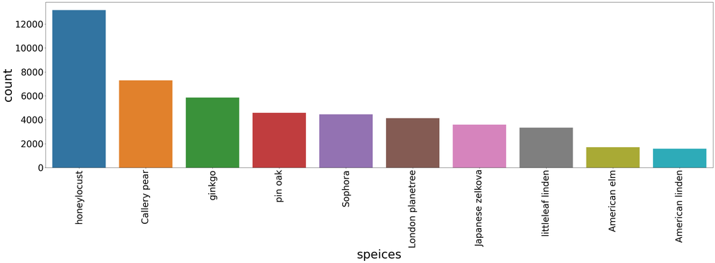

```python
fig , ax =plt.subplots(figsize =(40,10) )

g=sns.barplot(x='spc_common' , y='count' , data=com_spc.head(10) , estimator = 'sum' )
plt.xticks( rotation =90 , fontsize =30)
plt.yticks(fontsize = 30)
plt.xlabel('speices' , fontsize= 40)
plt.ylabel('count',fontsize = 40)
plt.show()
```

**Honeyoclust is one of the most common species with 21 percent of total spices of trees followed by Callery pear and ginko**

```python
trees[trees['status']== 'Alive']['health'].value_counts()
```

```
Good    47358
Fair    11460
Poor     3609
Name: health, dtype: int64
```

```python
##Extracting the names of top 10 trees spieces
listtop_MN = com_spc['spc_common'].head(10).unique()
listtop_MN
```

```
array(['honeylocust', 'Callery pear', 'ginkgo', 'pin oak', 'Sophora',
       'London planetree', 'Japanese zelkova', 'littleleaf linden',
       'American elm', 'American linden'], dtype=object)
```

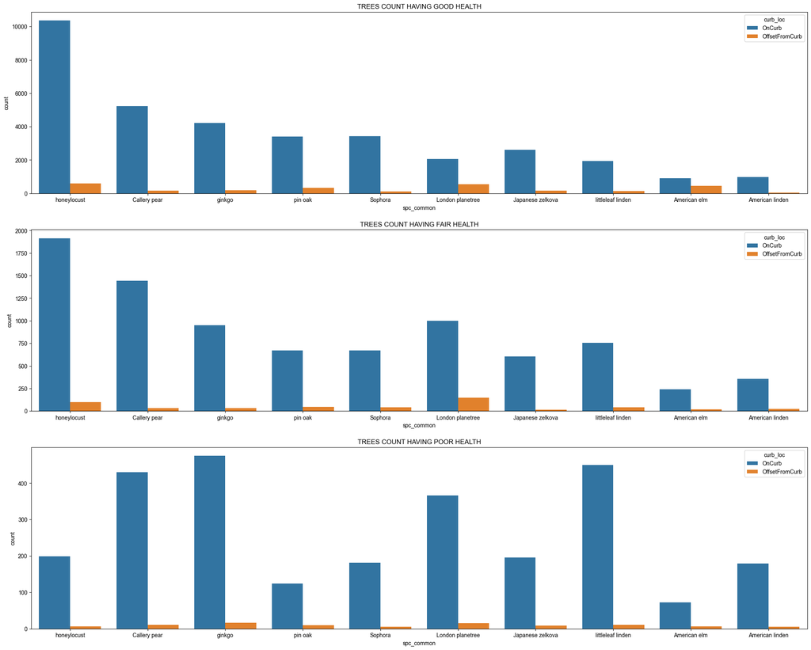

```python
#Visualizing the health and location of each of the 10 spieces

trees_topMN =trees[trees['spc_common'].isin(listtop_MN)]
trees_info=trees_topMN[[ 'spc_common', 'curb_loc', 'health']].value_counts(['spc_common', 'curb_loc', 'health']).reset_index(name='cnt')
trees_info
fig , ax = plt.subplots(3 , 1 , figsize= (25 , 20))
y1 = sns.countplot(ax=ax[0]  , data= trees_topMN[trees_topMN['health']=='Good']  , x='spc_common' , hue = 'curb_loc' , order =listtop_MN )
y1.set_title('TREES COUNT HAVING GOOD HEALTH' , y=1)

y2 = sns.countplot(ax=ax[1]  , data= trees_topMN[trees_topMN['health']=='Fair']  , x='spc_common' , hue = 'curb_loc'  , order = listtop_MN)
y2.set_title('TREES COUNT HAVING FAIR HEALTH' , y=1)

y3 = sns.countplot(ax=ax[2]  , data= trees_topMN[trees_topMN['health']=='Poor']  , x='spc_common' , hue = 'curb_loc'  , order= listtop_MN)
y3.set_title('TREES COUNT HAVING POOR HEALTH' , y=1)
sns.set_theme(style='whitegrid',palette='pastel', context='notebook')


plt.show()
```

```python
print(trees['curb_loc'].value_counts()/trees['curb_loc'].count()*100)
```

```
OnCurb            93.24491
OffsetFromCurb     6.75509
Name: curb_loc, dtype: float64
```

There is a huge difference in heath of trees found most in Manhattan when it comes to plantation on the curb compared to off the curb. This is because there only 6% trees of total trees which are planted off the curb. Hence our area of focus should be on the recommnedation on Curb Trees for future plantation as they are most widely used.

Diving deeper to the health status of all the top speices we get the fair idea that 'honeylocust' are one of the healthiest trees suited for Manhatten and therefore its confirms the fact that why they are planted more .

```python
trees_topMN=trees[trees['curb_loc']== 'OnCurb']
trees_topMN.head(10)
```

|  | tree_id | tree_dbh | curb_loc | spc_common | status | health | root_stone | root_grate | root_other | trunk_wire | trnk_light | trnk_other | brch_light | brch_shoe | brch_other | postcode | nta | nta_name | latitude | longitude |
| --- | --- | --- | --- | --- | --- | --- | --- | --- | --- | --- | --- | --- | --- | --- | --- | --- | --- | --- | --- | --- |
| 0 | 190422 | 11 | OnCurb | honeylocust | Alive | Good | No | No | No | No | No | No | No | No | No | 10023 | MN14 | Lincoln Square | 40.770046 | -73.984950 |
| 1 | 190426 | 11 | OnCurb | honeylocust | Alive | Good | No | No | No | No | No | No | No | No | No | 10023 | MN14 | Lincoln Square | 40.770210 | -73.985338 |
| 2 | 208649 | 9 | OnCurb | American linden | Alive | Good | No | Yes | No | No | No | No | No | No | No | 10019 | MN15 | Clinton | 40.762724 | -73.987297 |
| 3 | 193310 | 14 | OnCurb | honeylocust | Alive | Good | No | No | Yes | No | No | Yes | No | No | Yes | 10021 | MN40 | Upper East Side-Carnegie Hill | 40.772171 | -73.960456 |
| 4 | 199760 | 4 | OnCurb | willow oak | Alive | Fair | No | No | No | No | No | No | No | No | No | 10024 | MN12 | Upper West Side | 40.782087 | -73.980964 |
| 5 | 201555 | 9 | OnCurb | honeylocust | Alive | Good | No | No | No | No | No | No | No | No | No | 10002 | MN27 | Chinatown | 40.721807 | -73.989830 |
| 6 | 187056 | 7 | OnCurb | honeylocust | Alive | Good | No | Yes | No | No | No | Yes | No | No | No | 10023 | MN14 | Lincoln Square | 40.770396 | -73.981627 |
| 7 | 187058 | 5 | OnCurb | honeylocust | Alive | Good | No | Yes | No | No | No | Yes | No | No | No | 10023 | MN14 | Lincoln Square | 40.770227 | -73.981218 |
| 8 | 190423 | 12 | OnCurb | honeylocust | Alive | Good | No | No | No | No | No | No | No | No | No | 10023 | MN14 | Lincoln Square | 40.770087 | -73.985048 |
| 9 | 190425 | 13 | OnCurb | honeylocust | Alive | Good | No | No | No | No | No | No | No | No | No | 10023 | MN14 | Lincoln Square | 40.770181 | -73.985269 |

```python
trees_topMN1=trees[trees['curb_loc']== 'OnCurb'].value_counts('spc_common').head(10)
listtop_MN1= trees_topMN1.index.unique()
listtop_MN1
```

```
Index(['honeylocust', 'Callery pear', 'ginkgo', 'Sophora', 'pin oak',
       'Japanese zelkova', 'London planetree', 'littleleaf linden',
       'American linden', 'American elm'],
      dtype='object', name='spc_common')
```

## Neighborhoods with most trees.

```python
trees['nta'].count()
```

```
62427
```

```python
nbh_most_trees = trees[['nta' , 'nta_name']].value_counts().reset_index(name = 'trees_cnt')
nbh_most_trees.nlargest(10 , 'trees_cnt')
```

|  | nta | nta_name | trees_cnt |
| --- | --- | --- | --- |
| 0 | MN12 | Upper West Side | 5723 |
| 1 | MN40 | Upper East Side-Carnegie Hill | 4540 |
| 2 | MN23 | West Village | 3715 |
| 3 | MN03 | Central Harlem North-Polo Grounds | 3355 |
| 4 | MN13 | Hudson Yards-Chelsea-Flatiron-Union Square | 2797 |
| 5 | MN36 | Washington Heights South | 2788 |
| 6 | MN09 | Morningside Heights | 2642 |
| 7 | MN11 | Central Harlem South | 2581 |
| 8 | MN35 | Washington Heights North | 2519 |
| 9 | MN34 | East Harlem North | 2398 |

```python
nbh_most_trees['cum_sumperc']=nbh_most_trees['trees_cnt'].cumsum()/nbh_most_trees['trees_cnt'].sum()
nbh_most_trees['cum_sumperc']=nbh_most_trees['cum_sumperc'].apply(lambda x: x*100 )

nbh50perc=nbh_most_trees[nbh_most_trees['cum_sumperc']<= 50]
nbh50perc
```

|  | nta | nta_name | trees_cnt | cum_sumperc |
| --- | --- | --- | --- | --- |
| 0 | MN12 | Upper West Side | 5723 | 9.167508 |
| 1 | MN40 | Upper East Side-Carnegie Hill | 4540 | 16.440002 |
| 2 | MN23 | West Village | 3715 | 22.390953 |
| 3 | MN03 | Central Harlem North-Polo Grounds | 3355 | 27.765230 |
| 4 | MN13 | Hudson Yards-Chelsea-Flatiron-Union Square | 2797 | 32.245663 |
| 5 | MN36 | Washington Heights South | 2788 | 36.711679 |
| 6 | MN09 | Morningside Heights | 2642 | 40.943822 |
| 7 | MN11 | Central Harlem South | 2581 | 45.078251 |
| 8 | MN35 | Washington Heights North | 2519 | 49.113364 |

Trees count in Upper West Side is most with 5723 trees ,Since each neighborhood are not of same area this can be unfair to say and instead trees per unit area can be the other measure to rank neighborhoods with most trees.

```python
listnbh50perc= nbh50perc['nta_name'].unique()
listnbh50perc
```

```
array(['Upper West Side', 'Upper East Side-Carnegie Hill', 'West Village',
       'Central Harlem North-Polo Grounds',
       'Hudson Yards-Chelsea-Flatiron-Union Square',
       'Washington Heights South', 'Morningside Heights',
       'Central Harlem South', 'Washington Heights North'], dtype=object)
```

```python
##Merging the area parameter from geospacial data to trees survey
nbh_mst=nbh_MN[['ntacode' , 'ntaname']]
nbh_mst['area']=neighborhoods.area
nbh_mst
nbh_merged =nbh_mst.merge(nbh_most_trees , how='inner' , left_on='ntacode' , right_on='nta')
nbh_merged.sort_values('trees_cnt' , ascending= False)
```

|  | ntacode | ntaname | area | nta | nta_name | trees_cnt | cum_sumperc |
| --- | --- | --- | --- | --- | --- | --- | --- |
| 23 | MN12 | Upper West Side | 0.000341 | MN12 | Upper West Side | 5723 | 9.167508 |
| 2 | MN40 | Upper East Side-Carnegie Hill | 0.000199 | MN40 | Upper East Side-Carnegie Hill | 4540 | 16.440002 |
| 5 | MN23 | West Village | 0.000248 | MN23 | West Village | 3715 | 22.390953 |
| 11 | MN03 | Central Harlem North-Polo Grounds | 0.000252 | MN03 | Central Harlem North-Polo Grounds | 3355 | 27.765230 |
| 25 | MN13 | Hudson Yards-Chelsea-Flatiron-Union Square | 0.000367 | MN13 | Hudson Yards-Chelsea-Flatiron-Union Square | 2797 | 32.245663 |
| 27 | MN36 | Washington Heights South | 0.000229 | MN36 | Washington Heights South | 2788 | 36.711679 |
| 3 | MN09 | Morningside Heights | 0.000200 | MN09 | Morningside Heights | 2642 | 40.943822 |
| 17 | MN11 | Central Harlem South | 0.000143 | MN11 | Central Harlem South | 2581 | 45.078251 |
| 10 | MN35 | Washington Heights North | 0.000225 | MN35 | Washington Heights North | 2519 | 49.113364 |
| 16 | MN34 | East Harlem North | 0.000243 | MN34 | East Harlem North | 2398 | 52.954651 |
| 22 | MN04 | Hamilton Heights | 0.000160 | MN04 | Hamilton Heights | 2296 | 56.632547 |
| 21 | MN31 | Lenox Hill-Roosevelt Island | 0.000213 | MN31 | Lenox Hill-Roosevelt Island | 2215 | 60.180691 |
| 20 | MN19 | Turtle Bay-East Midtown | 0.000172 | MN19 | Turtle Bay-East Midtown | 2185 | 63.680779 |
| 1 | MN32 | Yorkville | 0.000135 | MN32 | Yorkville | 2133 | 67.097570 |
| 12 | MN24 | SoHo-TriBeCa-Civic Center-Little Italy | 0.000246 | MN24 | SoHo-TriBeCa-Civic Center-Little Italy | 2101 | 70.463101 |
| 24 | MN14 | Lincoln Square | 0.000157 | MN14 | Lincoln Square | 2008 | 73.679658 |
| 14 | MN15 | Clinton | 0.000182 | MN15 | Clinton | 1884 | 76.697583 |
| 15 | MN33 | East Harlem South | 0.000165 | MN33 | East Harlem South | 1877 | 79.704295 |
| 8 | MN28 | Lower East Side | 0.000231 | MN28 | Lower East Side | 1845 | 82.659747 |
| 19 | MN20 | Murray Hill-Kips Bay | 0.000143 | MN20 | Murray Hill-Kips Bay | 1661 | 85.320454 |
| 0 | MN22 | East Village | 0.000108 | MN22 | East Village | 1506 | 87.732872 |
| 9 | MN01 | Marble Hill-Inwood | 0.000176 | MN01 | Marble Hill-Inwood | 1438 | 90.036362 |
| 6 | MN27 | Chinatown | 0.000144 | MN27 | Chinatown | 1408 | 92.291797 |
| 13 | MN25 | Battery Park City-Lower Manhattan | 0.000189 | MN25 | Battery Park City-Lower Manhattan | 1264 | 94.316562 |
| 26 | MN21 | Gramercy | 0.000075 | MN21 | Gramercy | 1125 | 96.118667 |
| 18 | MN17 | Midtown-Midtown South | 0.000299 | MN17 | Midtown-Midtown South | 1120 | 97.912762 |
| 4 | MN06 | Manhattanville | 0.000106 | MN06 | Manhattanville | 865 | 99.298381 |
| 7 | MN50 | Stuyvesant Town-Cooper Village | 0.000055 | MN50 | Stuyvesant Town-Cooper Village | 438 | 100.000000 |

```python
##Adding Density field
nbh_merged ['density']=nbh_merged ['trees_cnt']/nbh_merged ['area']
nbh_merged[['ntacode' , 'ntaname' , 'density', 'trees_cnt']].sort_values('density' , ascending= False)
```

|  | ntacode | ntaname | density | trees_cnt |
| --- | --- | --- | --- | --- |
| 2 | MN40 | Upper East Side-Carnegie Hill | 2.283187e+07 | 4540 |
| 17 | MN11 | Central Harlem South | 1.803334e+07 | 2581 |
| 23 | MN12 | Upper West Side | 1.679328e+07 | 5723 |
| 1 | MN32 | Yorkville | 1.583196e+07 | 2133 |
| 26 | MN21 | Gramercy | 1.508174e+07 | 1125 |
| 5 | MN23 | West Village | 1.500413e+07 | 3715 |
| 22 | MN04 | Hamilton Heights | 1.438494e+07 | 2296 |
| 0 | MN22 | East Village | 1.395772e+07 | 1506 |
| 11 | MN03 | Central Harlem North-Polo Grounds | 1.331837e+07 | 3355 |
| 3 | MN09 | Morningside Heights | 1.321893e+07 | 2642 |
| 24 | MN14 | Lincoln Square | 1.281986e+07 | 2008 |
| 20 | MN19 | Turtle Bay-East Midtown | 1.267707e+07 | 2185 |
| 27 | MN36 | Washington Heights South | 1.216683e+07 | 2788 |
| 19 | MN20 | Murray Hill-Kips Bay | 1.159190e+07 | 1661 |
| 15 | MN33 | East Harlem South | 1.137271e+07 | 1877 |
| 10 | MN35 | Washington Heights North | 1.120273e+07 | 2519 |
| 21 | MN31 | Lenox Hill-Roosevelt Island | 1.039678e+07 | 2215 |
| 14 | MN15 | Clinton | 1.034434e+07 | 1884 |
| 16 | MN34 | East Harlem North | 9.874736e+06 | 2398 |
| 6 | MN27 | Chinatown | 9.805929e+06 | 1408 |
| 12 | MN24 | SoHo-TriBeCa-Civic Center-Little Italy | 8.535183e+06 | 2101 |
| 4 | MN06 | Manhattanville | 8.192915e+06 | 865 |
| 9 | MN01 | Marble Hill-Inwood | 8.175107e+06 | 1438 |
| 8 | MN28 | Lower East Side | 7.998206e+06 | 1845 |
| 7 | MN50 | Stuyvesant Town-Cooper Village | 7.932681e+06 | 438 |
| 25 | MN13 | Hudson Yards-Chelsea-Flatiron-Union Square | 7.625159e+06 | 2797 |
| 13 | MN25 | Battery Park City-Lower Manhattan | 6.699976e+06 | 1264 |
| 18 | MN17 | Midtown-Midtown South | 3.744378e+06 | 1120 |

Upper Easr Side-Carneight Hill has the highest density of trees in Manhattan area.

```python
pd.set_option('display.max_rows' , None)
```

**Manhattan currently have 97% of trees alive but we cant say the anything about the status of the trees health as it depends on various factors eg weather , location etc. Fortunality we have the health data collected for Manhattan.**

## Lets have a closer look to the spices distrubition in different categories over Map

```python
##Extracting trees with health status Good and Fair for recommendation
trees_topMN_FG=trees_topMN[trees_topMN['health'].isin(['Good' , 'Fair'])]
```

```python
piv_f_g =trees_topMN_FG.groupby(['spc_common' , 'health'])['spc_common'].count().sort_values(ascending=False).reset_index(name= 'cnt').head(10)

pd.pivot_table(piv_f_g ,index=['spc_common' ] , columns= 'health' , values = 'cnt')
```

| health spc_common | Fair | Good |
| --- | --- | --- |
| Callery pear | 1443.0 | 5226.0 |
| Japanese zelkova | NaN | 2616.0 |
| London planetree | NaN | 2048.0 |
| Sophora | NaN | 3432.0 |
| ginkgo | NaN | 4210.0 |
| honeylocust | 1914.0 | 10361.0 |
| littleleaf linden | NaN | 1937.0 |
| pin oak | NaN | 3397.0 |

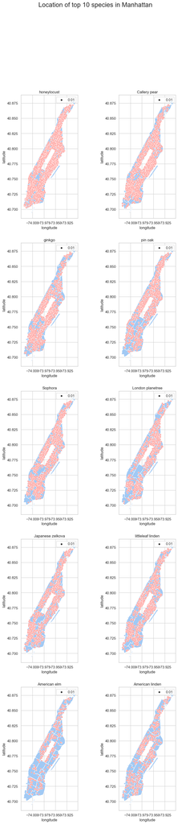

```python
##Visualizing the distribution of top10 trees across Mnahattan
def treedistribution(ax, spc, color):
    sns.scatterplot(y='latitude', x='longitude' , data= trees_topMN_FG[trees_topMN_FG['spc_common'] == str(spc)] , c= color , size=.01)

fig =plt.figure (figsize=(10,40))
plt.suptitle("Location of top 10 species in Manhattan" , fontsize= 20)
for c , i in enumerate(listtop_MN) :
    ax= plt.subplot(5, 2 , (c+1))
    nbh_MN.plot(ax=ax )
    treedistribution(ax,i , 'r')
    ax.set_title(str(i))
```

**As seen Honeylocust , Callery Pear are uniformly and densely planted compared to American elm and American linden sparsely planted. Major proportion of all the species are found in North and around Central Park of Manhattan.**

## SUMMARY

- honeylocust
- Callery pear
- ginkgo
- Sophora
- pin oak
- Japanese zelkova
- London planetree
- littleleaf linden
- American linden
- American elm

- Upper West Side
- Upper East Side-Carnegie Hill
- West Village
- Central Harlem South
- Morningside Heights
- Central Harlem South **are present in top list of density as well suggesting that these neighborhoods contributes both good count and density of plantation.**

**3. Vizualisation map helped in analyzing the distribution pattern of plantation of most planted healthy trees on the Curb:**

- Honeyoclust , Callery Pear are uniformly and densely planted compared to American elm and American linden sparsely planted.
- Major proportion of all the species are found in North and around Central Park of Manhattan,